# Assignment 5 (Data cleaning & preparation)

## Instructions

1. You may talk to a friend, discuss the questions and potential directions for solving them. However, you need to write your own solutions and code separately, and not as a group activity.
2. Do not write your name on the assignment.
3. Write your code in the *Code* cells and your answer in the *Markdown* cells of the Jupyter notebook. Ensure that the solution is written neatly enough to understand and grade.
4. Use [Quarto](https://quarto.org/docs/output-formats/html-basics.html) to print the *.ipynb* file as HTML. You will need to open the command prompt, navigate to the directory containing the file, and use the command: `quarto render filename.ipynb --to html`. Submit the HTML file.
5. The assignment is worth 100 points, and is due on **12th November 2022 at 11:59 pm**.
6. There is a bonus question worth 20 points, and an ultra bonus question worth 30 points. However, there is no partial credit for these questions. You will get 20 or 0 for the bonus question, and 30 or 0 for the ultra-bonus question. If everything is correct, you can score 150 out of 100 in the assignment.

## Missing value imputation

Read *Housing_missing_price.csv* as `housing_missing_price` and *Housing_complete.csv* as `housing_complete`. The datasets consist of housing features, like number of bedrooms, bathrooms, etc., and the price. Both datasets are exactly the same, except that *Housing_missing_price.csv* has some missing values of price. In this question, you will try different methods to impute the missing values of house price in the file *Housing_missing_price.csv*. You will use the prices in *Housing_complete.csv* to check the accuracy of your imputation.

Note that you **cannot** use *Housing_complete.csv* to impute missing `price` in any of the questions. *Housing_complete.csv* is just to check the accuracy of your imputation, after you have done the imputation. Before imputing the missing `price`, assume you do not have *Housing_complete.csv*.

```python
import pandas as pd
import numpy as np
import matplotlib.pyplot as plt
import seaborn as sns
```

```python
housing_missing_price = pd.read_csv('Housing_missing_price.csv')
housing_complete = pd.read_csv('Housing_complete.csv')
```

### Number of missing values

How many values of `price` are missing in *Housing_missing_price.csv*?

#### There are 25 missing values of “price”

*(3 points)*

```python
housing_missing_price.isnull().sum()['price']
```

```
25
```

### Indices of missing values

Find the row labels, where the `price` is missing. Assign those row labels as an array or a list to `index_null_price`.

*(4 points)*

```python
index_null_price = housing_missing_price[housing_missing_price['price'].isnull()].index.tolist()
```

### Correlation of continuous variables with `price`

Find the continuous variable having the highest correlation with `price`. Let the variable be $A_{cont}$.

*(2 points)*

```python
housing_missing_price.corrwith(housing_missing_price.price).sort_values(ascending = False)
```

```
price        1.000000
area         0.536065
bathrooms    0.521667
stories      0.415986
parking      0.384239
bedrooms     0.366228
dtype: float64
```

### The continuous varaible having the highest correlation with price is “area”.

### Missing value imputation using correlated continuous variable

Make a scatterplot of `price` against $A_{cont}$, with a trendline. Using the trendline, impute the missing values of `price`.

Plot the imputed `price` vs true `price` (from *Housing_complete.csv*) and print the RMSE (*Root mean squared error*). This is to be done only for the imputed values of `price`.

*(10 points)*

**Hint:**

1. Make the trendline using non-missing values of `price` and $A_{cont}$.
2. Impute the missing values of `price` only where they are missing, i.e., at row indices `index_null_price`.
3. You may use the function below to plot the imputed price vs true price (*from Housing_complete.csv*) and print the RMSE. The function assumes that `housing_imputed_price` is the *Housing_missing_price.csv* dataset, with imputed values of `price`.

```python
#Defining a function to plot the imputed values vs actual values
def plot_actual_vs_predicted():
    fig, ax = plt.subplots(figsize=(9, 6))
    plt.rc('xtick', labelsize=15)
    plt.rc('ytick', labelsize=15)
    x = housing_complete.loc[index_null_price,'price']/1e3
    y = housing_imputed_price.loc[index_null_price,'price']/1e3
    plt.scatter(x,y)
    z=np.polyfit(x,y,1)
    p=np.poly1d(z)
    plt.plot(x,x,color='orange')
    plt.xlabel('Actual price',fontsize=20)
    plt.ylabel('Imputed price',fontsize=20)
    ax.xaxis.set_major_formatter('${x:,.0f}k')
    ax.yaxis.set_major_formatter('${x:,.0f}k')
    rmse = np.sqrt(((x-y).pow(2)).mean())
    print("RMSE= $"+str(np.round(rmse,2))+"k")
```

```
RMSE= $1289.93k
```

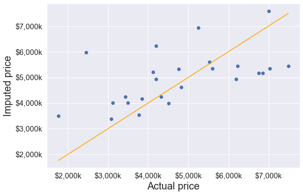

```python
x = housing_missing_price.area
y = housing_missing_price.price
idx_non_missing = np.isfinite(x) & np.isfinite(y)
slope_intercept_trendline = np.polyfit(x[idx_non_missing],y[idx_non_missing],1)   #Finding the slope and intercept for the trendline
compute_y_given_x = np.poly1d(slope_intercept_trendline)
#Creating a copy of missing data to impute missing values
housing_imputed_price = housing_missing_price.copy()
housing_imputed_price.loc[index_null_price,'price']=compute_y_given_x(housing_missing_price.loc[index_null_price,'area'])
plot_actual_vs_predicted()
```

### RSME = $1289.93k

### Correlation of categorical variables with `price`

Split the categorical columns of the *Housing_missing_price.csv*, such that they transform into dummy variables with each category corresponding to a column of 0s and 1s. The continuous variables remain as they were in the original dataset. Name this dataset as `housing_dummy`.

Which categorical variable is the most highly correlated with `price`? Let that variable be $V_{cat}$.

*(3 + 2 points)*

**Hint:** `pd.get_dummies()`

```python
housing_missing_copy = housing_missing_price.copy()
dummies_df = pd.get_dummies(housing_missing_copy, prefix=['mainroad', 'guestroom','basement',
                                     'hotwaterheating','airconditioning','prefarea','furnishingstatus'], prefix_sep='_',
                            columns=['mainroad', 'guestroom','basement',
                                     'hotwaterheating','airconditioning','prefarea','furnishingstatus'])
dummies_df.corrwith(dummies_df.price).sort_values(ascending = False)
```

```
price                              1.000000
area                               0.536065
bathrooms                          0.521667
airconditioning_yes                0.445848
stories                            0.415986
parking                            0.384239
bedrooms                           0.366228
prefarea_yes                       0.323378
mainroad_yes                       0.290889
guestroom_yes                      0.257309
furnishingstatus_furnished         0.220792
basement_yes                       0.195625
hotwaterheating_yes                0.094790
furnishingstatus_semi-furnished    0.074060
hotwaterheating_no                -0.094790
basement_no                       -0.195625
guestroom_no                      -0.257309
furnishingstatus_unfurnished      -0.282732
mainroad_no                       -0.290889
prefarea_no                       -0.323378
airconditioning_no                -0.445848
dtype: float64
```

### The categorical that is most highly correlated with price is air conditioning.

### Missing value imputation using correlated categorical variable

Impute the missing value of the `price` of a house as the average price of all the houses that have the same value of $V_{cat}$. For example, if $V_{cat}$ is `basement`, the missing price of a house that has a basement must be imputed as the average price of all the houses that have a basement, and the missing price of a house that lacks a basement must be imputed as the average price of all the houses that lack a basement.

Plot the imputed `price` vs true `price` (from *Housing_complete.csv*) and print the RMSE (Root mean squared error). This is to be done only for the imputed values of `price`.

*(10 points)*

```python
ac_yes = housing_missing_price[housing_missing_price['airconditioning']=='yes']['price'].mean()
ac_no = housing_missing_price[housing_missing_price['airconditioning']=='no']['price'].mean()
```

```python
frames = []
for i in list(set(housing_missing_price['airconditioning'])):
    df_ac = housing_missing_price[housing_missing_price['airconditioning']== i]
    df_ac['price'].fillna(df_ac['price'].mean(),inplace = True)
    frames.append(df_ac)
    housing_imputed_price = pd.concat(frames)
```

```
RMSE= $1173.22k
```

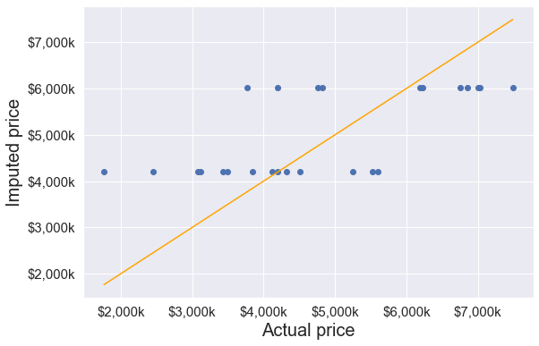

```python
plot_actual_vs_predicted()
```

### RSME = $1173.22k

### Missing value imputation using correlated continuous variable within the categories of correlated categorical variable

Execute the following code. Note that the trendlines of `price` against `area` are different based on `airconditioning`.

For each house, select the appropriate trendline to impute the missing `price`.

Plot the imputed price vs true price (from *Housing_complete.csv*) and print the RMSE (Root mean squared error). This is to be done only for the imputed values of `price`.

*(15 points)*

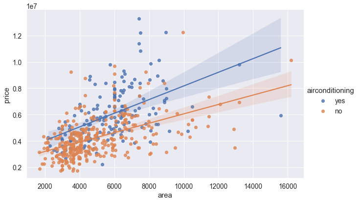

```python
sns.set(font_scale=1.25)
a = sns.FacetGrid(housing_missing_price, hue = 'airconditioning',height=6, aspect=1.5)
a.map(sns.regplot,'area','price')
a.add_legend()
```

```python
ac_yes_data = housing_missing_price.loc[housing_missing_price.airconditioning.isin(['yes']),:]
index_null_ac_yes = ac_yes_data[ac_yes_data['price'].isnull()].index.tolist()
ac_no_data = housing_missing_price.loc[housing_missing_price.airconditioning.isin(['no']),:]
index_null_ac_no = ac_no_data[ac_no_data['price'].isnull()].index.tolist()
```

```
RMSE= $1036.42k
```

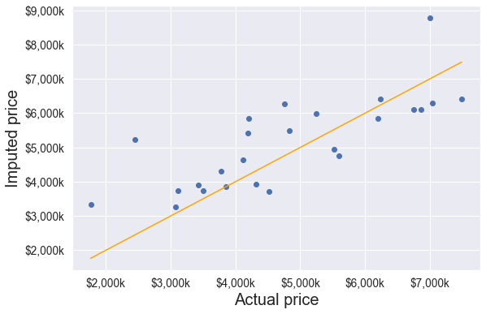

```python
housing_imputed_price = housing_missing_price.copy()
for response in ["yes","no"]:
    impute_index = list(np.where((housing_missing_price.price.isnull()) & (housing_missing_price.airconditioning==response))[0])
    x = housing_missing_price.loc[housing_missing_price.airconditioning==response,'area']
    y = housing_missing_price.loc[housing_missing_price.airconditioning==response,'price']
    idx_non_missing = np.isfinite(x) & np.isfinite(y)
    slope_intercept_trendline = np.polyfit(x[idx_non_missing],y[idx_non_missing],1)   #Finding the slope and intercept for the trendline
    compute_y_given_x = np.poly1d(slope_intercept_trendline)
#Creating a copy of missing data to impute missing values
    housing_imputed_price.loc[impute_index,'price']=compute_y_given_x(housing_missing_price.loc[impute_index,'area'])
plot_actual_vs_predicted()
```

### RSME = $1036.42k

### **Bonus** question: Missing value imputation with KNN

*(20 points)*

#### Identifying optimal $K$ by $k$-fold cross validation

You need to impute the missing `price` using the KNN ($K$-nearest neighbor) algorithm. However, before implementing the algorithm, find the optimal value of $K$, using $k$-fold cross-validation. Use all the variables in `housing_dummy`.

Note that you **cannot** use *Housing_complete.csv* to find the optimal $K$.

Follow the $k$-fold cross validation procedure below to find the optimal $K$, i.e., the optimal number of nearest neighbors to consider when imputing missing values:

1. Remove observations with missing `price` from `housing_missing_price`. Let us call the resulting DataFrame as `housing_missing_removed`.
2. Split `housing_missing_removed` into $k$-folds. Take $k=10$. Each fold will have one-tenth of the observations of `housing_missing_removed`.
3. Iterate over the $K^{th}$ potential value of $K$, where $K \in \{1,2,...,50\}$.

   A. Iterate over the $i^{th}$ fold, where $i \in \{1,2,...,10\}$

   I. Assume that the all the `price` values of the $i^{th}$ fold are missing. Impute the value of `price` for an observation in the $i^{th}$ fold as the mean `price` of the $K$-nearest neighbors to the observation, where the neighbors are from among the observations in the remaining 9 folds.
   2. Compute the RMSE (Root mean squared error) for the $i^{th}$ fold. Let us denote the RMSE for $i^{th}$ fold, and considering $K$ nearest neighbors as $RMSE_{iK}$.

   B. Find the average of the 10 RMSEs obtained in 3(A). Let us denote it as $RMSE_K$, i.e., RMSE for a given value of $K$. Then,
   $$RMSE_K = \frac{1}{10} \sum_{i=1}^{i=10} RMSE_{iK}$$
4. The optimal value of $K$ is the one for which $RMSE_K$ is the minimum, i.e.,
   $$K_{optimal}=\underset{K \in \{1,...,50\}}{\operatorname{\ argmin}} RMSE_K$$

#### Implementing KNN with optimal $K$

Using the optimal value of $K = K_{optimal}$ obtained in the previous question, impute the missing values of `price` in `housing_missing_price`. Use all the variables in `housing_dummy` for implementing the KNN algorithm. Plot the imputed price vs true price (from *Housing_complete.csv*) and print the RMSE (Root mean squared error). This is to be done only for the imputed values of `price`.

### **Ultra-bonus** question

*(30 points)*

Develop an algorithm to impute the missing `price`, such that it reduces the imputation RMSE to below $650k. Plot the imputed price vs true price (from *Housing_complete.csv*) and print the RMSE (Root mean squared error). This is to be done only for the imputed values of `price`.

*Note that we have not attempted to solve this question yet. We are not sure if there exists a solution. However, if you find a solution, you will get 30 points.*

*If you think you are successful, email your solution to krish@northwestern.edu for grading.*

## Binning

Read *house_features_and_price.csv*. We will bin a couple of variables to better analyze the trend of `house_price` with those variables.

```python
house_features_price = pd.read_csv('house_features_and_price.csv')
```

### Trend with `house_age`

Make a scatterplot of `house_price` against `house_age`, along with the trendline. What is the trend indicated by the trendline?

*(4 points)*

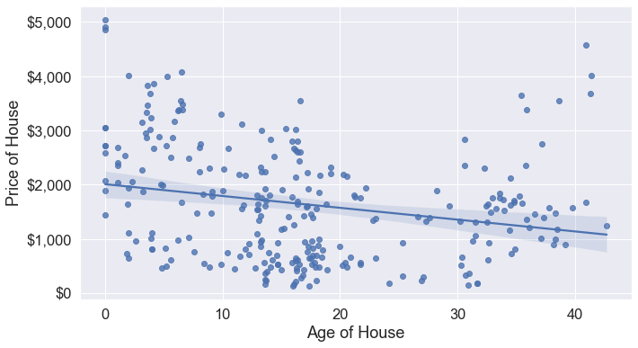

```python
sns.set(font_scale=1.5)
g = sns.regplot(
    data=house_features_price, x="house_age", y="house_price")
g.set(xlabel='Age of House',
       ylabel='Price of House')
g.yaxis.set_major_formatter('${x:,.0f}')
```

### It’s not a great association but the trendline indicates that as the house’s age increases, its price tends to decrease.

### Trend with bins of `house_age`

Bin `house_age` into 5 approximately equal-sized bins.

*(3 points)*

After binning, plot the mean `house_price` against the house age bins.

*(3 points)*

Is the trend seen with this plot different from that seen with the trendline in the previous question? If yes, then is one of the trends incorrect? Why or why not?

*(4 points)*

Is one of the trends more informative? If yes, then which one and how?

*(4 points)*

```python
#Part 1
house_features_copy = house_features_price.copy()
house_age_binned = pd.qcut(house_features_copy['house_age'],5,retbins = True)
house_features_copy['House_Age_Bin'] = house_age_binned[0]
```

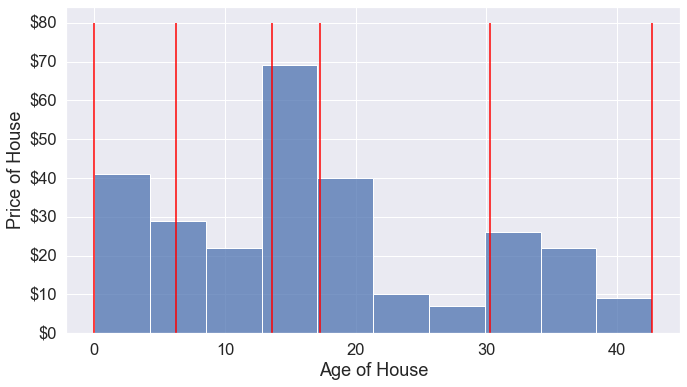

```python
#Part 1 continued
sns.set(font_scale=1.5)
ax=sns.histplot(data = house_features_copy, x= 'house_age')
plt.vlines(house_age_binned[1], 0,80,color='red')
plt.xlabel('Age of House');
plt.ylabel('Price of House');
ax.yaxis.set_major_formatter('${x:,.0f}')
```

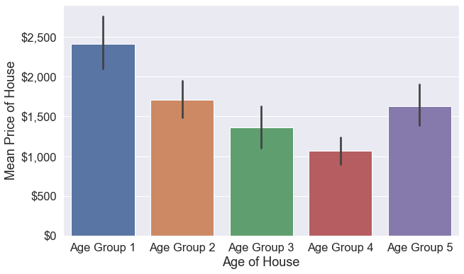

```python
#Part 2
house_features_copy['House_Age_Bin'] = pd.qcut(house_features_copy['house_age'],5,labels = ['Age Group 1','Age Group 2','Age Group 3','Age Group 4','Age Group 5'])
plt.rcParams["figure.figsize"] = (10,6)
a=sns.barplot(x = 'House_Age_Bin', y = 'house_price', data = house_features_copy)
plt.xlabel('Age of House')
plt.ylabel('Mean Price of House')
a.yaxis.set_major_formatter('${x:,.0f}')
```

### Part 3

#### Overall, the plot above generally reflects the scatterplot and trendline in the original question. There is a general decrease in price as age increases. However, there seems to be a disconnect between the trendline and the increase in mean price for the last age group. I believe the scatterplot trendline is more reliable as it shows some high price values for the a few of the older houses, and this is probably pulling up the mean of the oldest houses while the scatteplot shows aa majority of the data points following the general direction of the trendline.

### Part 4

#### Even though the bar plot is a bit skewed at the end due to it using mean house price values that are being influenced by a few high data points, I think it is generally more informative. While I can discern the general trend from the scatterplot, there is enough variability that makes the plot noisy. The barchart maps the trend in a more clear fashion and is able to capture the relative difference in house prices for each age bin.

### Trend with `number_convenience_stores`

Make a barplot to visualize the mean `house_price` against `number_convenience_stores`.

*(3 points)*

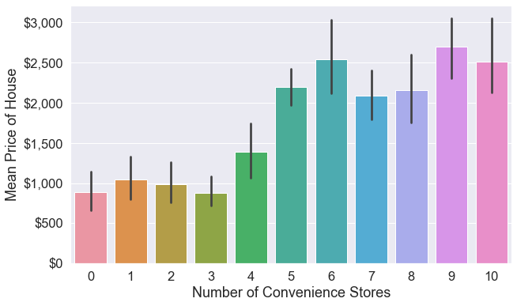

```python
b=sns.barplot(x = 'number_convenience_stores', y = 'house_price', data = house_features_price)
plt.xlabel('Number of Convenience Stores')
plt.ylabel('Mean Price of House')
b.yaxis.set_major_formatter('${x:,.0f}')
```

### Trend with bins of `number_convenience_stores`

Bin `number_convenience_stores` into an appropriate number of bins such that the non-linear trend of the variation of `house_price` with the bins of `number_convenience_stores` is retained, while minimizing the number of bins.

After binning, plot the mean `house_price` against the `number_convenience_stores` bins.

*(8 points)*

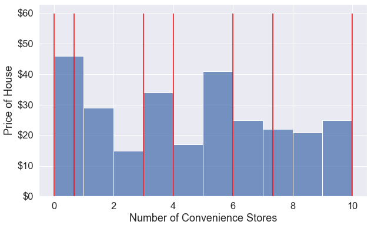

```python
house_features_copy2 = house_features_price.copy()
convenience_binned = pd.qcut(house_features_copy2['number_convenience_stores'],6,retbins = True)
house_features_copy2['Convenience_Bin'] = convenience_binned[0]
sns.set(font_scale=1.5)
ax2=sns.histplot(data = house_features_copy2, x= 'number_convenience_stores')
plt.vlines(convenience_binned[1], 0,60,color='red')
plt.xlabel('Number of Convenience Stores');
plt.ylabel('Price of House');
ax2.yaxis.set_major_formatter('${x:,.0f}')
```

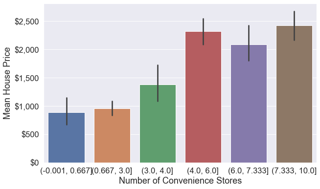

```python
ax3 = sns.barplot(x='Convenience_Bin', y='house_price', data = house_features_copy2)
ax3.yaxis.set_major_formatter('${x:,.0f}')
plt.xlabel('Number of Convenience Stores')
plt.ylabel('Mean House Price')
```

### Size of `number_convenience_stores` bins

Print the size of bins obtained in the previous question. Are the bins of approximately equal size? If not, is it reasonable to have bins of unequal sizes to visualize the trend of `house_price` with `number_convenience_stores`.?

*(2 + 4 points)*

```python
print(convenience_binned[0].value_counts())
```

```
(0.667, 3.0]       78
(4.0, 6.0]         66
(-0.001, 0.667]    46
(7.333, 10.0]      46
(6.0, 7.333]       22
(3.0, 4.0]         17
Name: number_convenience_stores, dtype: int64
```

### The bins are not of equal width and yes it is reasonable to have bins of unequal sizes when necessary to visualise a trend. Having bins of equal size may impact the ability of showing a higher proportion/incidence of certain data points. For something like number of convenience stores, it is logical to expect uneven distribituons in their numbers across the data set. Houses are most likely in different settings (rural/urban) which impacts the number of convenience stores values.

## Outliers

### Identifying outlying prices

Continue using `house_features_and_price.csv`. How many houses have outlying values of `house_price`. Are these houses extremely expensive or extremely cheap?

*(6 + 2 points)*

```python
q1 = np.percentile(house_features_price['house_price'],25)
q3 = np.percentile(house_features_price['house_price'],75)
intQ_range = q3-q1
Lower_fence = q1 - 1.5*intQ_range
Upper_fence = q3 + 1.5*intQ_range
Outlying_obs = house_features_price[(house_features_price.house_price<Lower_fence) | (house_features_price.house_price>Upper_fence)]
Outlying_obs
```

|  | house_id | house_age | distance_MRT | number_convenience_stores | latitude | longitude | house_price |
| --- | --- | --- | --- | --- | --- | --- | --- |
| 35 | 379 | 0.0 | 292.9978 | 6 | 24.97744 | 121.54458 | 4858.09 |
| 54 | 105 | 0.0 | 292.9978 | 6 | 24.97744 | 121.54458 | 5041.00 |
| 98 | 16 | 0.0 | 292.9978 | 6 | 24.97744 | 121.54458 | 4914.01 |

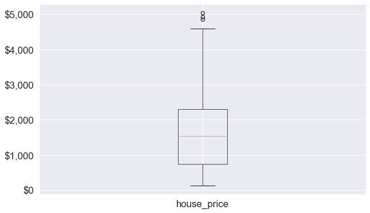

```python
ax2=house_features_price.boxplot(column = 'house_price')
ax2.yaxis.set_major_formatter('${x:,.0f}')
```

### Basded on the first part, there are three outlying values. According to the boxplot, these outliers are on the expensive side.

### Quick EDA

How are these houses (identified in the previous question as outliers) different from the houses in the rest of the dataset, which might be making them extremely expensive / extremely cheap? Explore the data and mention your hypothesis.

*(8 points)*

```python
house_features_price.describe()
```

|  | house_id | house_age | distance_MRT | number_convenience_stores | latitude | longitude | house_price |
| --- | --- | --- | --- | --- | --- | --- | --- |
| count | 275.000000 | 275.000000 | 275.000000 | 275.000000 | 275.000000 | 275.000000 | 275.000000 |
| mean | 214.210909 | 17.044000 | 1082.468346 | 4.134545 | 24.968829 | 121.533440 | 1638.283347 |
| std | 119.409034 | 11.146371 | 1252.552883 | 2.991485 | 0.012056 | 0.015455 | 1050.427272 |
| min | 2.000000 | 0.000000 | 49.661050 | 0.000000 | 24.932070 | 121.473530 | 125.440000 |
| 25% | 115.500000 | 8.350000 | 289.324800 | 1.000000 | 24.962990 | 121.527590 | 737.145000 |
| 50% | 215.000000 | 16.100000 | 492.231300 | 4.000000 | 24.970260 | 121.538740 | 1544.490000 |
| 75% | 318.500000 | 22.900000 | 1557.038500 | 6.000000 | 24.977335 | 121.543480 | 2299.205000 |
| max | 413.000000 | 42.700000 | 6488.021000 | 10.000000 | 25.014590 | 121.566270 | 5041.000000 |

#### Based on the data, these houses share the same characteristics and this combination must make them expensive. These houses aren’t on any extreme ends of any column except age (brand new) and price obviously. I believe that their latitudes/longitudes probably represent a prime location or piece of land. Combine that with the houses being brand new and MRT distances well below the mean and 50% quartile value, theses locations probably provide an easy way to commute to work while being on a particularly valuable piece of land.